# Codebook: Study on value creation model of science-society interactions

Irene Ramos-Vielba, Nicolas Robinson-Garcia and Richard Woolley

March 18, 2022

# Brief description

This is document reproduces the figures produced in the study ‘A value creation model for science-society interconnections: Archetypal analysis combining publications, survey and altmetric data’ authored by I. Ramos-Vielba, N. Robinson-Garcia /& R. Woolley. Data is available at [doi:10.5281/zenodo.6393226](https://doi.org/10.5281/zenodo.6393226). Code scripts are available in a (GitHub repository)[https://github.com/elrobin/value-components].

# Data import and processing

Data is imported from Zenodo. It includes 9,190 observations and 12 variables.

```r
df <- read.csv(
  "https://zenodo.org/record/6393226/files/dataset_archetypes_v3.csv?download=1", sep = ";"
)
str(df)
```

```
## 'data.frame':    9190 obs. of  12 variables:
##  $ ï..id        : int  2 4 6 7 8 10 11 12 13 14 ...
##  $ field        : chr  "STEM" "STEM" "SSH" "SSH" ...
##  $ production   : int  0 0 0 0 0 0 3 0 2 0 ...
##  $ engagement   : int  0 0 0 0 2 1 2 0 1 0 ...
##  $ translation  : int  0 0 0 0 0 1 1 0 2 0 ...
##  $ dissemination: int  2 1 1 1 3 2 1 2 4 1 ...
##  $ transmission : int  2 3 1 1 4 3 4 4 4 1 ...
##  $ PUBS         : int  6 8 3 1 9 27 4 8 21 23 ...
##  $ OA           : int  4 1 1 1 7 20 1 6 7 17 ...
##  $ p_twitter    : int  1 2 1 0 4 15 0 4 16 17 ...
##  $ p_news       : int  1 0 0 0 1 1 0 0 2 1 ...
##  $ p_policy     : int  0 0 0 0 0 1 0 0 2 0 ...
```

We create non-size dependent variables based on publications by converting these into proportions and we then rename them to match the naming of the value creation model.

```r
df$pp_news <- df$p_news / df$PUBS
df$pp_policy <- df$p_policy / df$PUBS
df$pp_oa <- df$OA / df$PUBS
df$pp_twitter <- df$p_twitter / df$PUBS

df <- df %>% # Select and rename variables
  select(
    ï..id,
    translation,
    dissemination,
    engagement,
    production,
    pp_news,
    pp_oa,
    pp_policy,
    pp_twitter,
    transmission,
    field
  )

names(df) <- c(
  "ID_FINAL",
  "Commercialisation",
  "Dissemination",
  "Engagement",
  "Joint research",
  "Media promotion",
  "Openness",
  "Public Policy",
  "Social visibility",
  "Transmission",
  "field"
)
```

# Figures

## Descriptives

The following table corresponds to Table 5 in the paper, and includes basic descriptives per field:

- BIOMED. Biomedicine
- SSH. Social Sciences and Humanities
- STEM. Science, Technology, Engineering and Mathematics.

```r
df.vars <- df %>%
  tidyr::pivot_longer(!field & !ID_FINAL,
                      names_to = "variable",
                      values_to = "value")

df.vars %>%
  group_by(field, variable) %>%
summarise(n = n(), mean = mean(value), sd = sd(value))
```

```
## # A tibble: 27 x 5
## # Groups:   field [3]
##    field  variable              n    mean     sd
##    <chr>  <chr>             <int>   <dbl>  <dbl>
##  1 BIOMED Commercialisation  2130 0.516   1.02
##  2 BIOMED Dissemination      2130 1.53    0.657
##  3 BIOMED Engagement         2130 1.18    1.31
##  4 BIOMED Joint research     2130 0.843   1.15
##  5 BIOMED Media promotion    2130 0.0454  0.107
##  6 BIOMED Openness           2130 0.452   0.328
##  7 BIOMED Public Policy      2130 0.00876 0.0564
##  8 BIOMED Social visibility  2130 0.468   0.307
##  9 BIOMED Transmission       2130 2.64    0.966
## 10 SSH    Commercialisation  1950 0.204   0.569
## # ... with 17 more rows
```

## Correlation matrix

Next we create a correlation matrix including also the distribution of each variable. This figure corresponds to Figure 2.

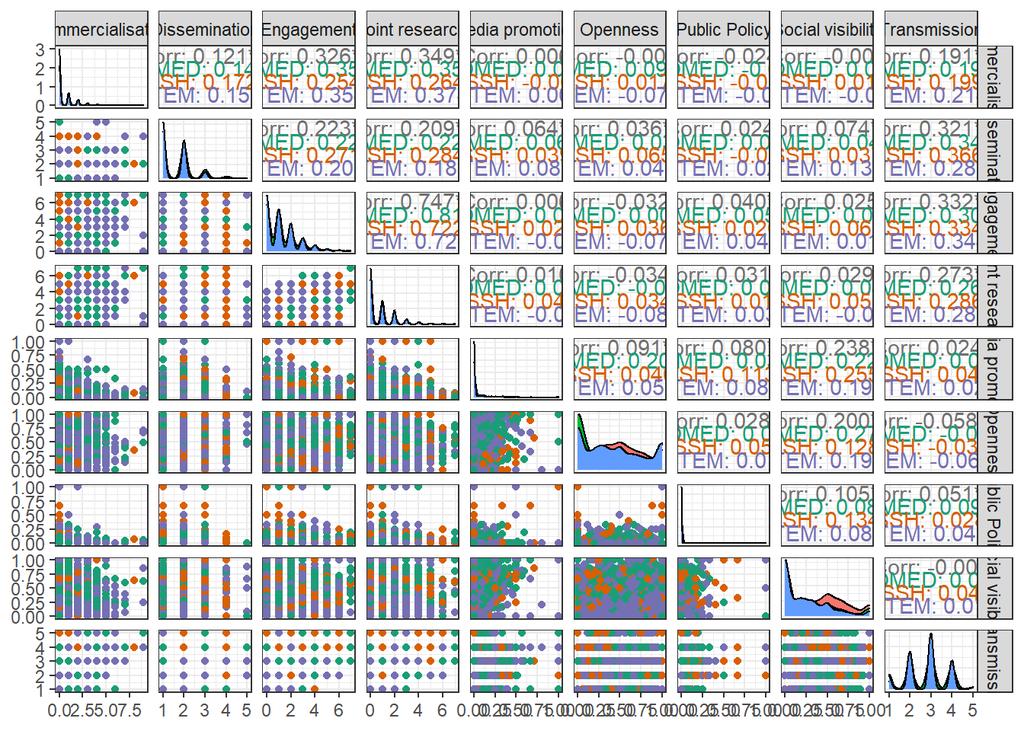

```r
  ggpairs(df, columns=2:10, aes(colour = field)) +
    theme_bw() + scale_color_brewer(palette = "Dark2")
```

## Archetypal analyses

Following we include the archetypal analyses constructed for each field and overall.

### All cases

The archetypal analysis for all cases is displayed in the manuscript in Figure 3.

#### Identification of archetypes

We first identify the ideal number of archetypes needed. We search for the best model looking at up to 5 archetypes and 5 repetitions.

```r
all <- df %>%
  select(!field & !ID_FINAL)

set.seed(1986)
arc.k <- stepArchetypes(data = all,
                        k = 1:5,
                        verbose =F,
                        nrep = 5)
```

The optimal number of archetypes is selected based on the Residual Sum of Squares (RSS) for which we apply an elbow rule.

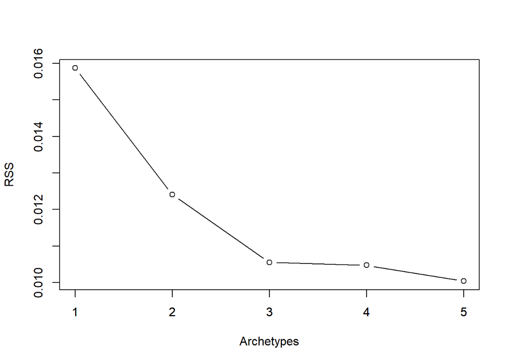

```r
screeplot(arc.k) # 3 archetypes
```

#### Characterization of archetypes

These archetypes have the following parameters

```r
arc.model <- bestModel(arc.k[[3]])
t(parameters(arc.model))
```

```
##                            [,1]        [,2]          [,3]
## Commercialisation -7.757858e-05 2.161637740 -1.001852e-05
## Dissemination      1.059851e+00 2.569063945  1.636289e+00
## Engagement        -1.887014e-04 4.720686563  1.612700e-01
## Joint research    -1.217999e-04 3.682235114 -1.572927e-05
## Media promotion   -4.329948e-06 0.002978228  1.604448e-01
## Openness           2.671435e-01 0.293303339  8.886213e-01
## Public Policy     -9.299296e-07 0.002915692  3.286608e-02
## Social visibility -4.577995e-05 0.211122389  1.000014e+00
## Transmission       2.149042e+00 4.484772213  2.249856e+00
```

Which can be better interpreted when plotted in percentiles:

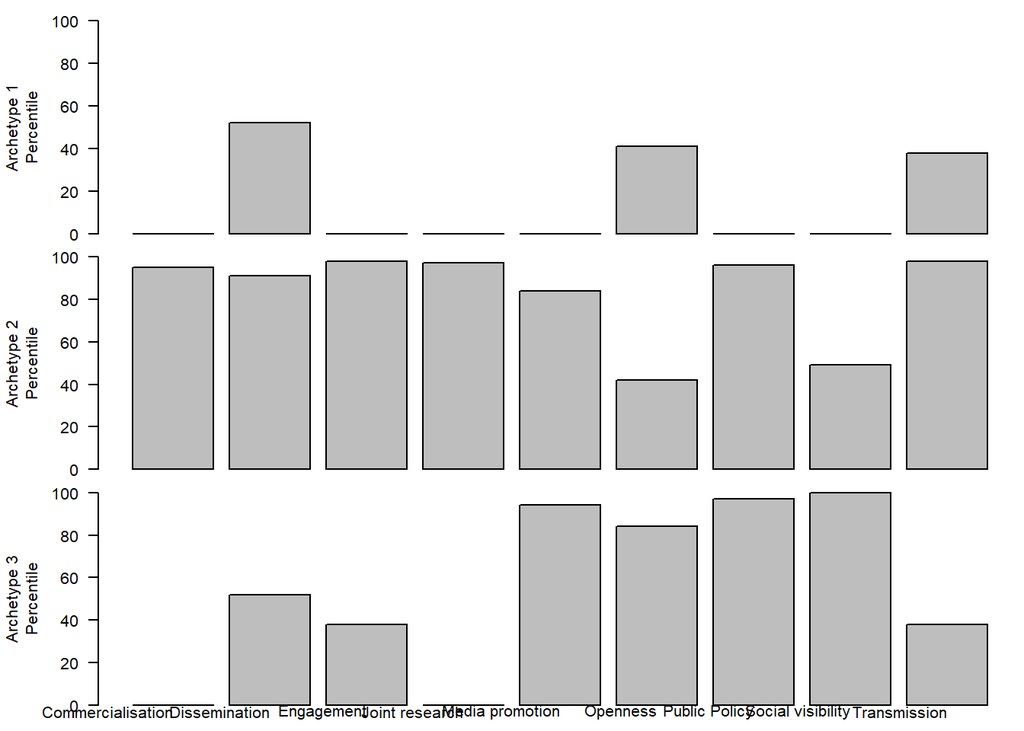

```r
barplot(arc.model, all, percentiles = TRUE)
```

In the manuscript these percentiles are shown using a radar chart for which we first have to recalculate those percentiles as computed in the `archetypes` package.

```r
.perc <- function(x, data, digits = 2) { # Calculates percentiles
  Fn <- ecdf(data)
  round(Fn(x) * 1, digits = digits)
}

param <- parameters(arc.model)


atypes <- param # extract parameters
rownames(atypes) <- sprintf('Archetype %s',
                            seq(length = nrow(atypes)))

atypes <- sapply(seq(length = ncol(all)), # Identify percentile for param
                 function(i)              # based on a data.frame
                   .perc(atypes[, i], all[, i]))

colnames(atypes) <- colnames(all)
atypes <- as.data.frame(atypes)

atypes$archetype <- c(1,2,3)
```

We can then produce the radar charts after converting from wide to long format

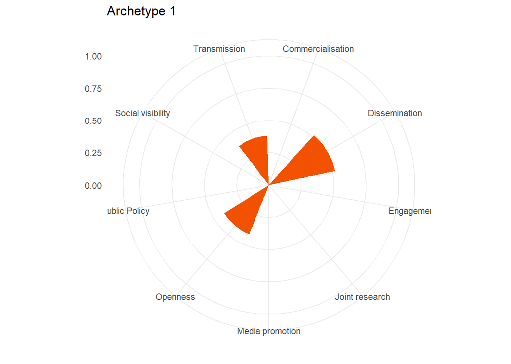

```r
params <-
  tidyr::pivot_longer(atypes,
                      !c("archetype"),
                      names_to = "variable",
                      values_to = "value")
a1 <-
  ggplot(subset(params, archetype == 1)) +
  geom_col(aes(x = variable, y = value), fill = "#F25200") +
  ylim(0, 1) +
  labs(title = "Archetype 1",
       x = element_blank(),
       y = element_blank()) +
  coord_polar() +
  theme_minimal()

a2 <-
  ggplot(subset(params, archetype == 2)) +
  geom_col(aes(x = variable, y = value), fill = "#F25200") +
  ylim(0, 1) +
  labs(title = "Archetype 2",
       x = element_blank(),
       y = element_blank()) +
  coord_polar() +
  theme_minimal()

a3 <-
  ggplot(subset(params, archetype == 3)) +
  geom_col(aes(x = variable, y = value), fill = "#F25200") +
  ylim(0, 1) +
  labs(title = "Archetype 3",
       x = element_blank(),
       y = element_blank()) +
  coord_polar() +
  theme_minimal()

par(mfrow = c(3, 1))
a1
```

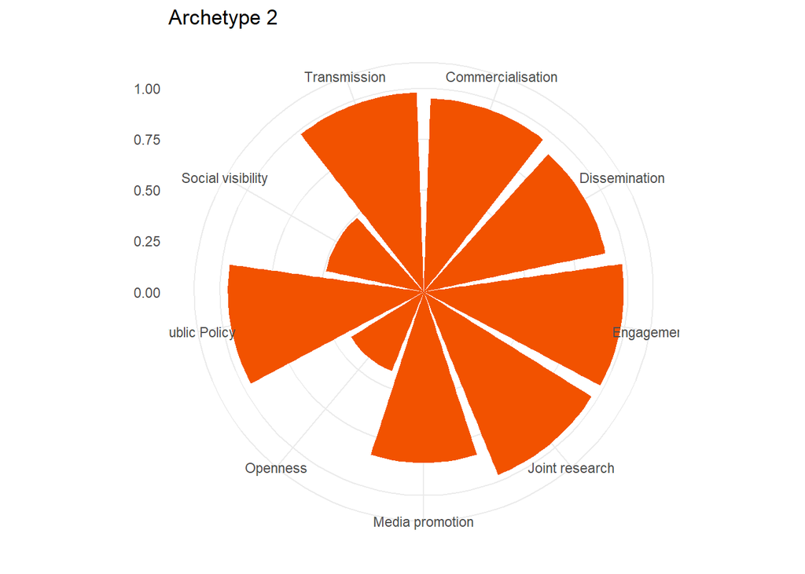

```r
a2
```

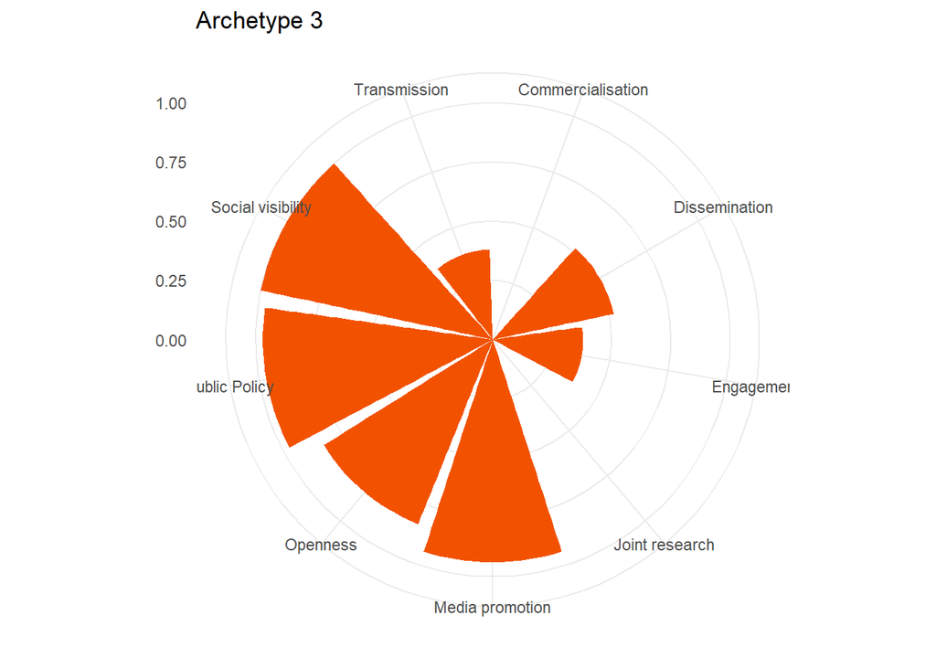

```r
a3
```

Co-occurrence term maps overlaying alpha scores for researchers’ scientific output is available online here: (https://sl.ugr.es/allarchetypes)[https://sl.ugr.es/allarchetypes]. Below find the code to extract the alpha score of each observation for the three archetypes:

```r
# alphas <- arc.model[["alphas"]]
#
# alphas <- cbind.data.frame(df$ID_FINAL, alphas)
# write.csv(alphas, file = "alpha-all-respondents.csv", quote = F,
#            row.names = F,)
```

### STEM

The archetypal analysis for STEM cases is displayed in the manuscript in Figure 4.

#### Identification of archetypes

We first identify the ideal number of archetypes needed. We search for the best model looking at up to 5 archetypes and 5 repetitions.

```r
stem <- df %>%
  filter(field=="STEM") %>%
  select(!field & !ID_FINAL)

set.seed(1986)
arc.k <- stepArchetypes(data = stem,
                        k = 1:5,
                        verbose =F,
                        nrep = 5)
```

The optimal number of archetypes is selected based on the Residual Sum of Squares (RSS) for which we apply an elbow rule.

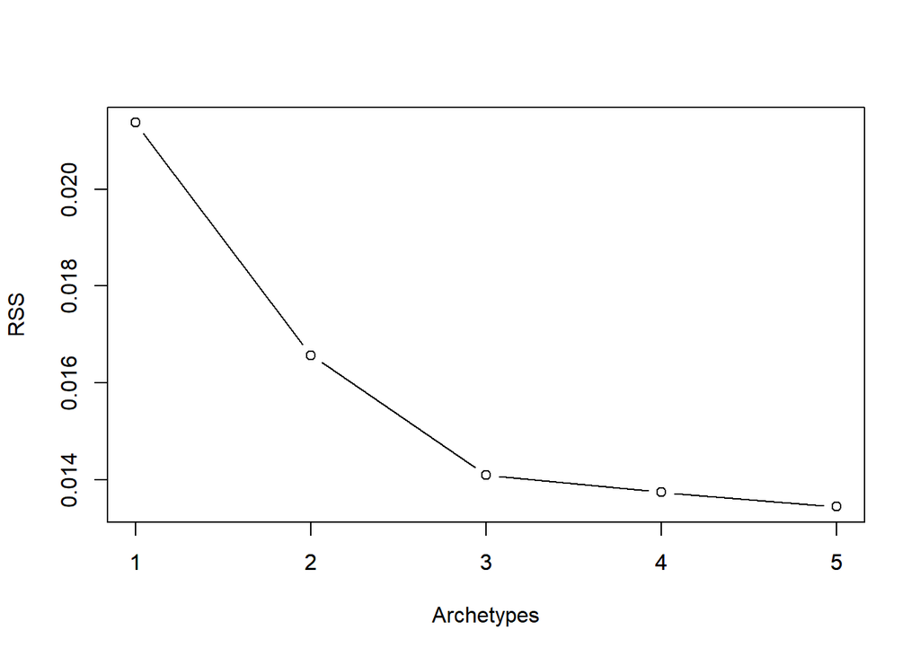

```r
screeplot(arc.k) # 3 archetypes
```

#### Characterization of archetypes

These archetypes have the following parameters

```r
arc.model <- bestModel(arc.k[[3]])
t(parameters(arc.model))
```

```
##                         [,1]          [,2]          [,3]
## Commercialisation 0.01604539  3.768879e+00 -2.583331e-05
## Dissemination     2.81910316  2.256802e+00  9.999774e-01
## Engagement        0.60094009  6.174208e+00  2.661862e-02
## Joint research    0.08654360  4.996007e+00 -3.404266e-05
## Media promotion   0.15813300  9.279789e-03 -9.314300e-07
## Openness          0.95195089  1.965541e-01  3.342719e-01
## Public Policy     0.02884634 -5.550278e-07 -1.570726e-07
## Social visibility 0.99619348  1.074052e-01  3.384643e-02
## Transmission      3.52332288  4.527561e+00  1.998948e+00
```

Which can be better interpreted when plotted in percentiles:

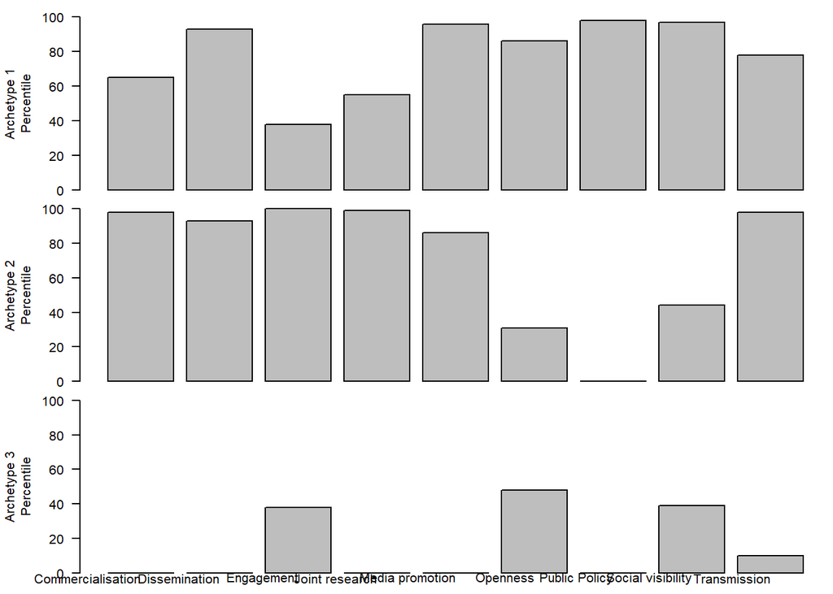

```r
barplot(arc.model, stem, percentiles = TRUE)
```

In the manuscript these percentiles are shown using a radar chart for which we first have to recalculate those percentiles as computed in the `archetypes` package.

```r
stemtypes <- parameters(arc.model) # extract parameters
rownames(stemtypes) <- sprintf('Archetype %s',
                               seq(length = nrow(stemtypes)))

stemtypes <-
  sapply(seq(length = ncol(stem)), # Identify percentile for param
         function(i)
           # based on a data.frame
           .perc(stemtypes[, i], stem[, i]))

colnames(stemtypes) <- colnames(stem)
stemtypes <- as.data.frame(stemtypes)

stemtypes$archetype <- c(1, 2, 3)
```

We can then produce the radar charts after converting from wide to long format

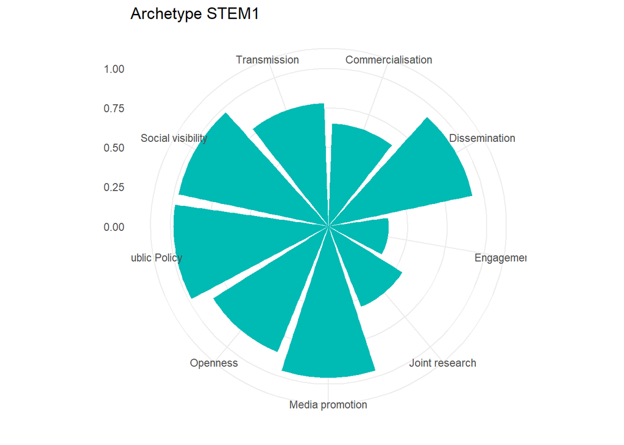

```r
params <-
  tidyr::pivot_longer(stemtypes,
                      !c("archetype"),
                      names_to = "variable",
                      values_to = "value")
a1 <-
  ggplot(subset(params, archetype == 1)) +
  geom_col(aes(x = variable, y = value), fill = "#00BAB4") +
  ylim(0, 1) +
  labs(title = "Archetype STEM1",
       x = element_blank(),
       y = element_blank()) +
  coord_polar() +
  theme_minimal()

a2 <-
  ggplot(subset(params, archetype == 2)) +
  geom_col(aes(x = variable, y = value), fill = "#00BAB4") +
  ylim(0, 1) +
  labs(title = "Archetype STEM2",
       x = element_blank(),
       y = element_blank()) +
  coord_polar() +
  theme_minimal()

a3 <-
  ggplot(subset(params, archetype == 3)) +
  geom_col(aes(x = variable, y = value), fill = "#00BAB4") +
  ylim(0, 1) +
  labs(title = "Archetype STEM3",
       x = element_blank(),
       y = element_blank()) +
  coord_polar() +
  theme_minimal()

par(mfrow = c(3, 1))
a1
```

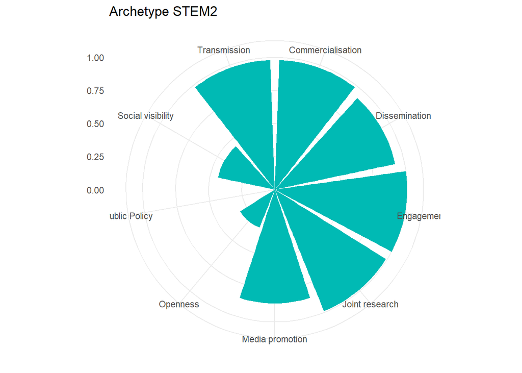

```r
a2
```

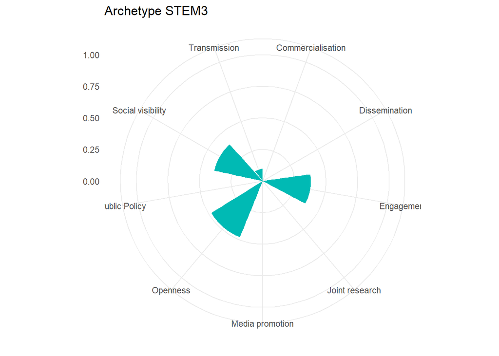

```r
a3
```

Co-occurrence term maps overlaying alpha scores for researchers’ scientific output is available online here: (https://sl.ugr.es/stemarchetypes)[https://sl.ugr.es/stemarchetypes]. Below find the code to extract the alpha score of each observation for the three archetypes:

```r
alphas <- arc.model[["alphas"]]

df.stem <- subset (df,
                   field=="STEM",
                   select =
                     c("ID_FINAL"))
alphas <- cbind.data.frame(df.stem, alphas)

write.csv(alphas, file = "alpha-stem-respondents.csv", quote = F,
          row.names = F)
```

### SSH

#### Identification of archetypes

We first identify the ideal number of archetypes needed. We search for the best model looking at up to 5 archetypes and 5 repetitions.

```r
ssh <- df %>%
  filter(field=="SSH") %>%
  select(!field & !ID_FINAL)

set.seed(1986)
arc.k <- stepArchetypes(data = ssh,
                        k = 1:5,
                        verbose =F,
                        nrep = 5)
```

The optimal number of archetypes is selected based on the Residual Sum of Squares (RSS) for which we apply an elbow rule.

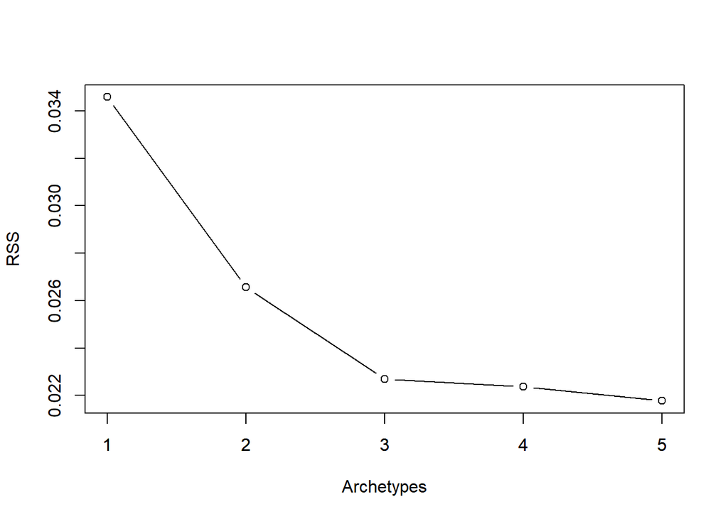

```r
screeplot(arc.k) # 3 archetypes
```

#### Characterization of archetypes

These archetypes have the following parameters

```r
arc.model <- bestModel(arc.k[[3]])
t(parameters(arc.model))
```

```
##                            [,1]          [,2]          [,3]
## Commercialisation -3.908118e-05 -9.167116e-05  1.332944e+00
## Dissemination      1.836354e+00  1.228259e+00  3.354170e+00
## Engagement         4.353993e-01  1.203056e-02  5.540208e+00
## Joint research    -1.305979e-04 -3.063383e-04  4.553506e+00
## Media promotion    2.683900e-01 -1.093877e-05 -5.440266e-07
## Openness           8.491478e-01  2.276740e-01  3.456086e-01
## Public Policy      1.067694e-01 -4.008930e-06 -1.993792e-07
## Social visibility  1.000144e+00  6.682204e-03  2.387494e-01
## Transmission       2.986753e+00  2.186739e+00  4.708219e+00
```

Which can be better interpreted when plotted in percentiles:

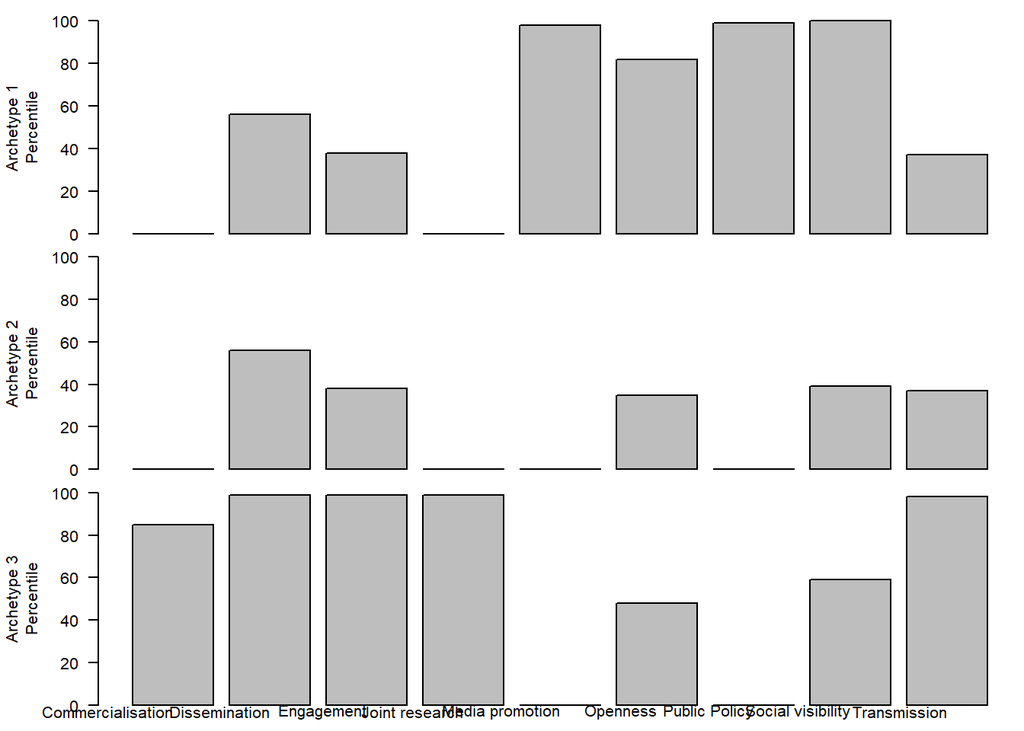

```r
barplot(arc.model, stem, percentiles = TRUE)
```

In the manuscript these percentiles are shown using a radar chart for which we first have to recalculate those percentiles as computed in the `archetypes` package.

```r
sshtypes <- parameters(arc.model) # extract parameters
rownames(sshtypes) <- sprintf('Archetype %s',
                               seq(length = nrow(sshtypes)))

sshtypes <-
  sapply(seq(length = ncol(ssh)), # Identify percentile for param
         function(i)
           # based on a data.frame
           .perc(sshtypes[, i], ssh[, i]))

colnames(sshtypes) <- colnames(ssh)
sshtypes <- as.data.frame(sshtypes)

sshtypes$archetype <- c(1, 2, 3)
```

We can then produce the radar charts after converting from wide to long format

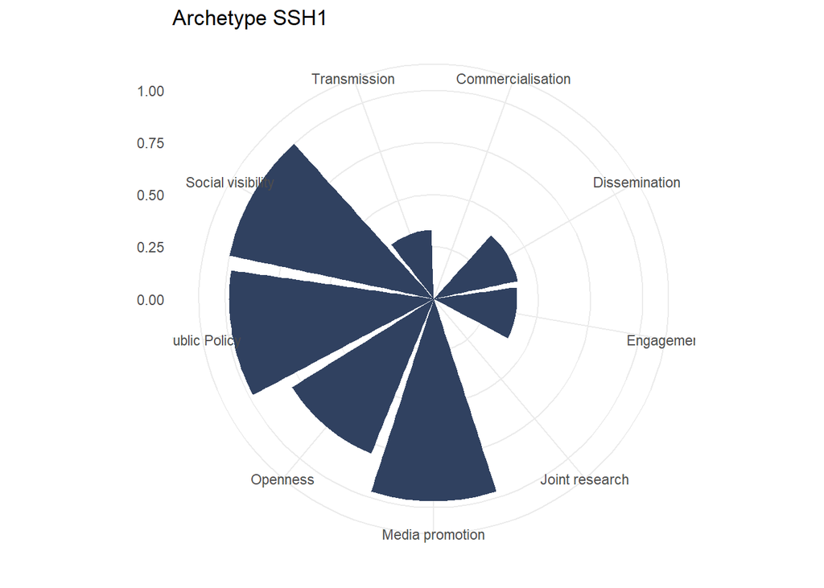

```r
params <-
  tidyr::pivot_longer(sshtypes,
                      !c("archetype"),
                      names_to = "variable",
                      values_to = "value")
a1 <-
  ggplot(subset(params, archetype == 1)) +
  geom_col(aes(x = variable, y = value), fill = "#304160") +
  ylim(0, 1) +
  labs(title = "Archetype SSH1",
       x = element_blank(),
       y = element_blank()) +
  coord_polar() +
  theme_minimal()

a2 <-
  ggplot(subset(params, archetype == 2)) +
  geom_col(aes(x = variable, y = value), fill = "#304160") +
  ylim(0, 1) +
  labs(title = "Archetype SSH2",
       x = element_blank(),
       y = element_blank()) +
  coord_polar() +
  theme_minimal()

a3 <-
  ggplot(subset(params, archetype == 3)) +
  geom_col(aes(x = variable, y = value), fill = "#304160") +
  ylim(0, 1) +
  labs(title = "Archetype SSH3",
       x = element_blank(),
       y = element_blank()) +
  coord_polar() +
  theme_minimal()

par(mfrow = c(3, 1))
a1
```

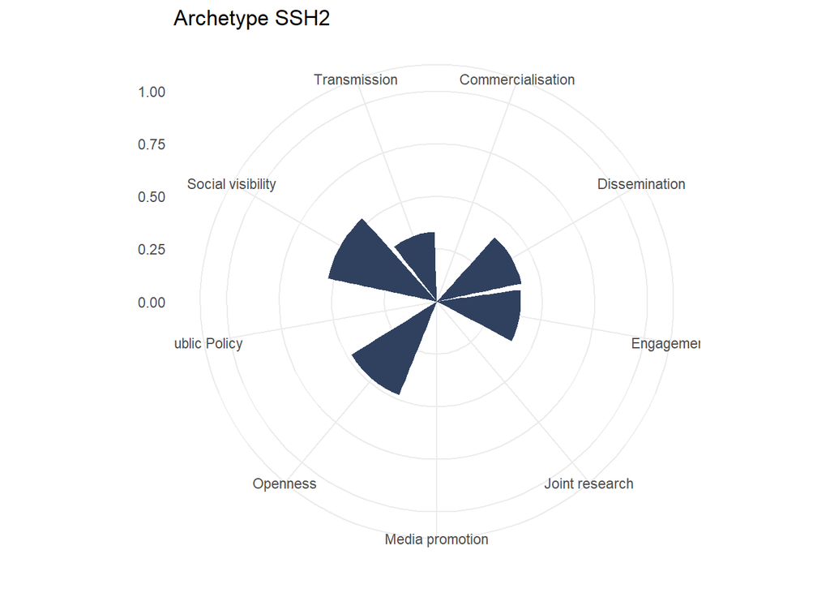

```r
a2
```

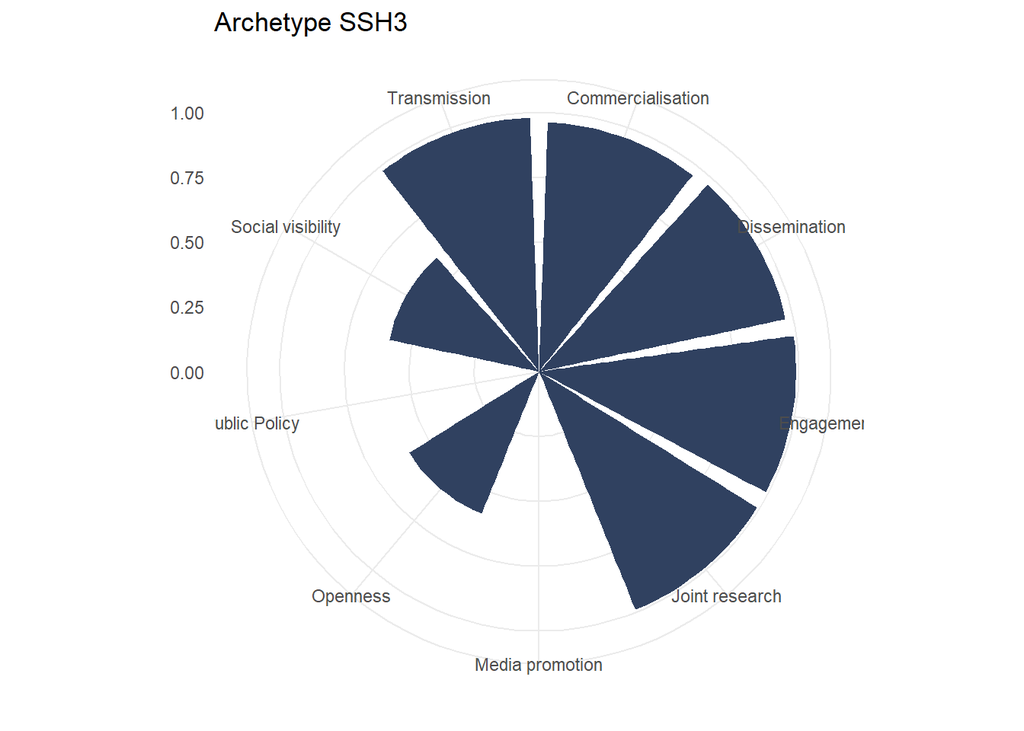

```r
a3
```

Co-occurrence term maps overlaying alpha scores for researchers’ scientific output is available online here: (https://sl.ugr.es/ssharchetypes)[https://sl.ugr.es/ssharchetypes].

Below find the code to extract the alpha score of each observation for the three archetypes:

```r
alphas <- arc.model[["alphas"]]

df.ssh <- subset (df,
                   field=="SSH",
                   select =
                     c("ID_FINAL"))
alphas <- cbind.data.frame(df.ssh, alphas)

write.csv(alphas, file = "alpha-ssh-respondents.csv", quote = F,
          row.names = F)
```

### BIOMED

The archetypal analysis for BIOMED cases is displayed in the manuscript in Figure 6.

#### Identification of archetypes

We first identify the ideal number of archetypes needed. We search for the best model looking at up to 5 archetypes and 5 repetitions.

```r
biomed <- df %>%
  filter(field=="BIOMED") %>%
  select(!field & !ID_FINAL)

set.seed(1986)
arc.k <- stepArchetypes(data = biomed,
                        k = 1:5,
                        verbose =F,
                        nrep = 5)
```

The optimal number of archetypes is selected based on the Residual Sum of Squares (RSS) for which we apply an elbow rule.

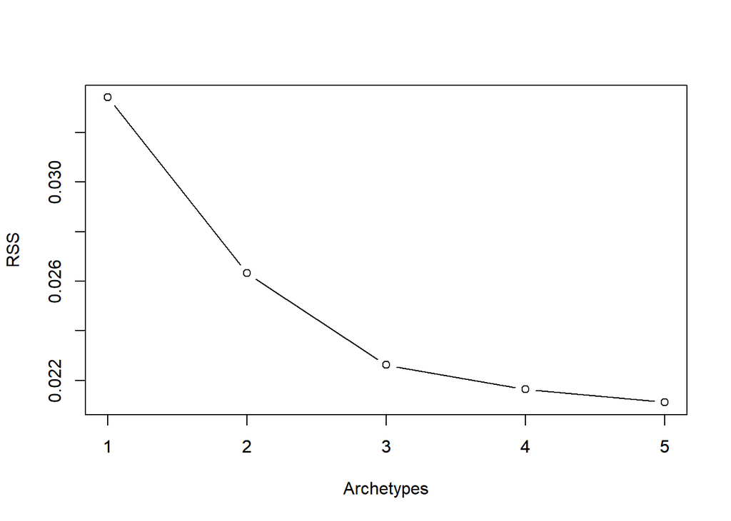

```r
screeplot(arc.k) # 3 archetypes
```

#### Characterization of archetypes

These archetypes have the following parameters

```r
arc.model <- bestModel(arc.k[[3]])
t(parameters(arc.model))
```

```
##                         [,1]          [,2]          [,3]
## Commercialisation 3.07979927 -1.767756e-04  0.0843188406
## Dissemination     2.81549356  9.998176e-01  1.5483899379
## Engagement        6.25715223  1.420711e-02  0.0425973732
## Joint research    5.28038138 -2.884656e-04 -0.0001042772
## Media promotion   0.03903413 -1.553638e-05  0.1766949736
## Openness          0.36402621  3.680102e-03  1.0000678203
## Public Policy     0.02486743 -2.998000e-06  0.0188674871
## Social visibility 0.42116353  2.958519e-02  1.0000658582
## Transmission      4.71199755  2.004295e+00  2.3233634364
```

Which can be better interpreted when plotted in percentiles:

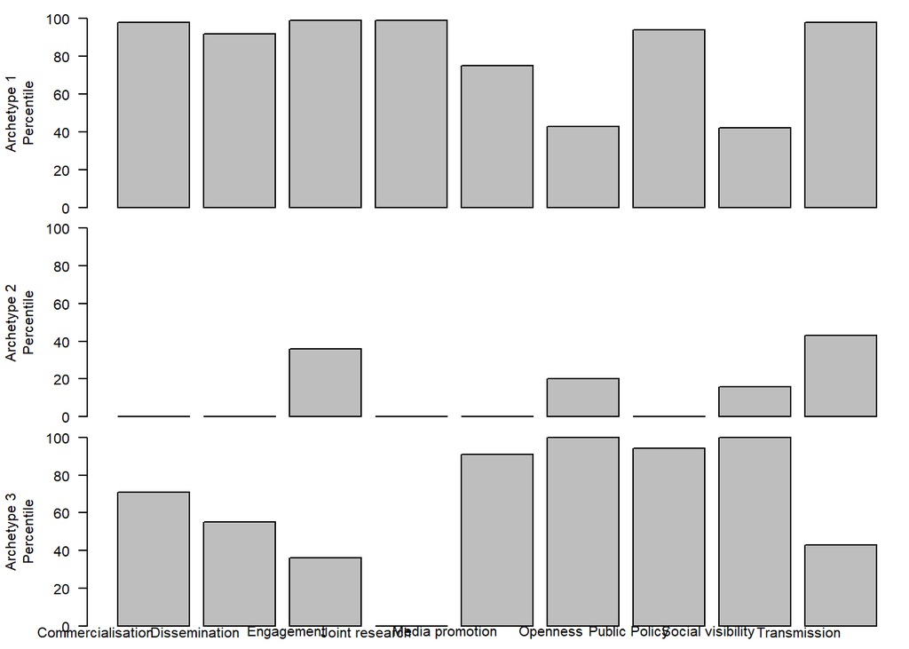

```r
barplot(arc.model, biomed, percentiles = TRUE)
```

In the manuscript these percentiles are shown using a radar chart for which we first have to recalculate those percentiles as computed in the `archetypes` package.

```r
biomedtypes <- parameters(arc.model) # extract parameters
rownames(biomedtypes) <- sprintf('Archetype %s',
                               seq(length = nrow(biomedtypes)))

biomedtypes <-
  sapply(seq(length = ncol(biomed)), # Identify percentile for param
         function(i)
           # based on a data.frame
           .perc(biomedtypes[, i], biomed[, i]))

colnames(biomedtypes) <- colnames(biomed)
biomedtypes <- as.data.frame(biomedtypes)

biomedtypes$archetype <- c(1, 2, 3)
```

We can then produce the radar charts after converting from wide to long format

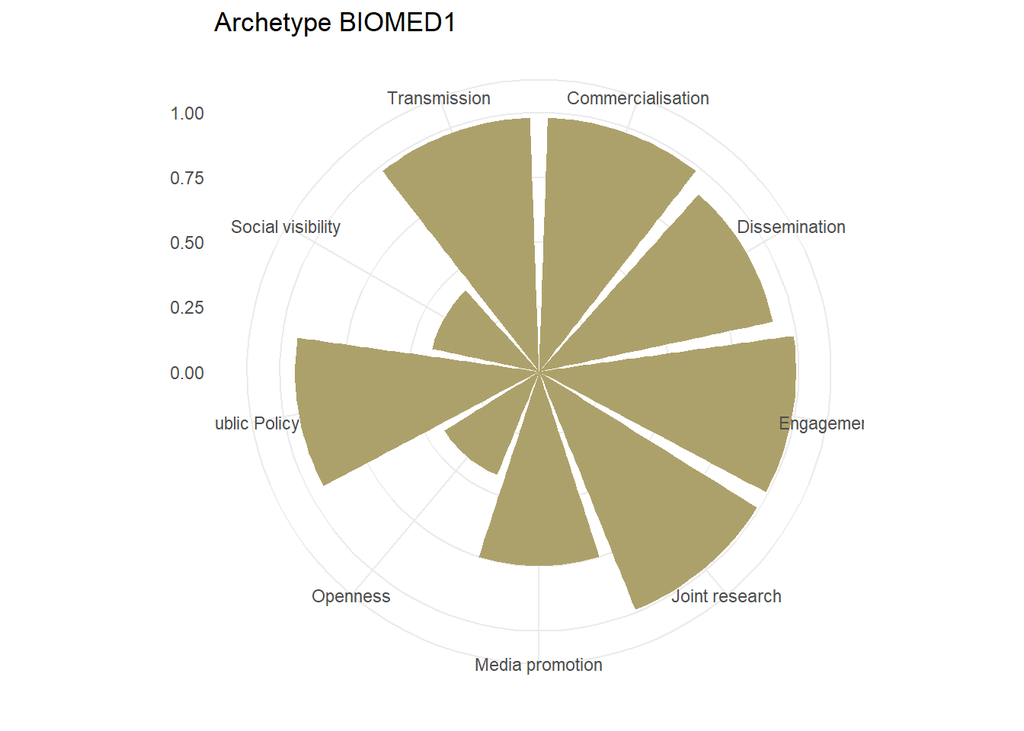

```r
params <-
  tidyr::pivot_longer(biomedtypes,
                      !c("archetype"),
                      names_to = "variable",
                      values_to = "value")
a1 <-
  ggplot(subset(params, archetype == 1)) +
  geom_col(aes(x = variable, y = value), fill = "#ADA16B") +
  ylim(0, 1) +
  labs(title = "Archetype BIOMED1",
       x = element_blank(),
       y = element_blank()) +
  coord_polar() +
  theme_minimal()

a2 <-
  ggplot(subset(params, archetype == 2)) +
  geom_col(aes(x = variable, y = value), fill = "#ADA16B") +
  ylim(0, 1) +
  labs(title = "Archetype BIOMED2",
       x = element_blank(),
       y = element_blank()) +
  coord_polar() +
  theme_minimal()

a3 <-
  ggplot(subset(params, archetype == 3)) +
  geom_col(aes(x = variable, y = value), fill = "#ADA16B") +
  ylim(0, 1) +
  labs(title = "Archetype BIOMED3",
       x = element_blank(),
       y = element_blank()) +
  coord_polar() +
  theme_minimal()

par(mfrow = c(3, 1))
a1
```

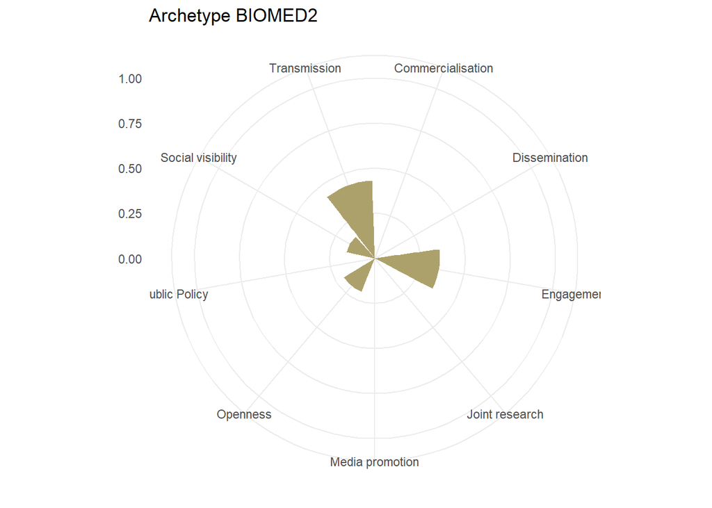

```r
a2
```

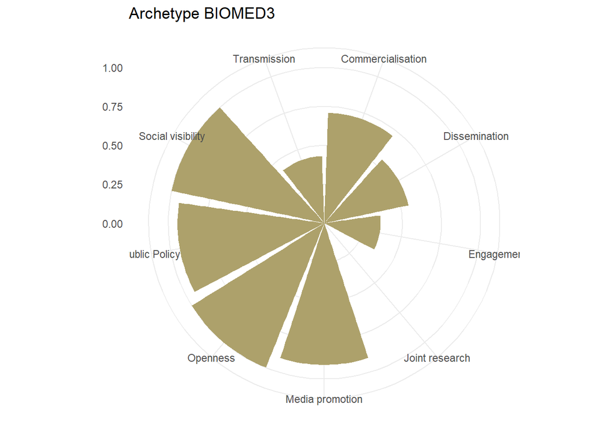

```r
a3
```

Co-occurrence term maps overlaying alpha scores for researchers’ scientific output is available online here: (https://sl.ugr.es/biomedarchetypes)[https://sl.ugr.es/biomedarchetypes]. Below find the code to extract the alpha score of each observation for the three archetypes:

```r
alphas <- arc.model[["alphas"]]

df.biomed <- subset (df,
                   field=="BIOMED",
                   select =
                     c("ID_FINAL"))
alphas <- cbind.data.frame(df.biomed, alphas)

write.csv(alphas, file = "alpha-biomed-respondents.csv", quote = F,
          row.names = F)
```